# Results

This Markdown file reproduces all results for the manuscript entitled “Regularized parametric survival modeling to improve risk prediction models”.

Authors: J Hoogland, TPA Debray, MJ Crowther, RD Riley, J IntHout, JB Reitsma, AH Zwinderman Code was written by J Hoogland In case of questions or comments please contact j.hoogland@amsterdamumc.nl

All Figures are stored in folder `./figures` instead of being rendered.

# 1 Simulation study

This sections reproduces all results and figures based on the provided intermediate results. For replication of the intermediate results, please refer to the README file.

## 1.1 Main simulation study

```r
dir <- "intermediates/"

# load all output file names
files <- list.files(dir)

# select those belonging to the main simulation study
files <- grep("survsim[0-9].*RData", files, value = TRUE)

# number of simulations
(nsim <- length(files))
```

```
#> [1] 1000
```

```r
# load the files
numextract <- function(string){
  as.numeric(str_extract(string, "\\-*\\d+"))
}
files <- files[order(numextract(files))]

# put everything into a single object sr
sr <- plyr::llply(paste0(dir, files), function(x){
  load(x)
  return(list=(r=results))}, .progress = "none")

# object sr now contains all simulation results
# each sim gets the its own name
names(sr) <- paste0("sim", numextract(files))

# Rearrange hierarchy of results to method > iteration > scenario > measures
sr <- do.call(function(...) Map(list, ...), sr)

nn <- 4 # number of scenarios
sample.size.settings <- 1:4
nmethods <- 10 # number of methods
methods <- c("RegHazTV", "RegCumHazTV", "CoxPH", "CoxTV", "CoxPHlasso", "CoxTVridge", "RPrcsPH",
             "RPrcsTV", "RPssPH", "RPssTV")
```

### 1.1.1 Figures (main)

All figures for the main manuscript are rendered as .eps (vector type) and stored in the `figures` folder. Supplementary material plots (calibration and discrimination performance) are rendered as .pdf and are also stored in the `figures` folder.

```r
dir <- "figures/"
postfix <- ""
filetype <- ".eps"
source("sim/figures_sim.R")
```

Median processing times in minutes

```r
tt <- round(apply(times, c(1,2), median) / 60, 1)
dimnames(tt) <- list(c(paste0("N=", c(100, 250, 500, 100))),
                     c(methods))
tt
```

```
#>       RegHazTV RegCumHazTV CoxPH CoxTV CoxPHlasso CoxTVridge RPrcsPH RPrcsTV
#> N=100      2.7         1.1     0     0          0        1.1       0       0
#> N=250      5.9         1.3     0     0          0        2.9       0       0
#> N=500     13.3         1.4     0     0          0        5.3       0       0
#> N=100     28.4         1.9     0     0          0       10.1       0       0
#>       RPssPH RPssTV
#> N=100      0    0.4
#> N=250      0    1.3
#> N=500      0    2.8
#> N=100      0    6.8
```

## 1.2 Higher censoring

For the settings with increased censoring, the R code is exactly analogous to the above code for the main settings. It is of course included in the `.Rmd` file, but not shown here.

### 1.2.1 Figures (higher censoring)

All figures for the main manuscript are rendered as .eps (vector type) and stored in the `figures` folder. Supplementary material plots (calibration and discrimination performance) are rendered as .pdf and are also stored in the `figures` folder.

```r
dir <- "figures/"
postfix <- "highcens"
filetype <- ".eps"
source("sim/figures_sim.R")
```

## 1.3 Higher number of covariates

For the settings with a higher number of covariates, the R code is exactly analogous to the above code for the main settings. It is of course included in the `.Rmd` file, but not shown here.

### 1.3.1 Figures (higher p)

All figures for the main manuscript are rendered as .eps (vector type) and stored in the `figures` folder. Supplementary material plots (calibration and discrimination performance) are rendered as .pdf and are also stored in the `figures` folder.

```r
dir <- "figures/"
postfix <- "highp"
filetype <- ".eps"
source("sim/figures_sim.R")
```

### 1.3.2 Data generating mechinism figure

```r
S0 <- function(lambdas, gammas, pmix, t){
  (pmix * exp(-lambdas[1] * t^(gammas[1])) + (1-pmix) * exp(-lambdas[2] * t^(gammas[2])))
}
H0 <- function(lambdas, gammas, pmix, t){
  -log(pmix * exp(-lambdas[1] * t^(gammas[1])) + (1-pmix) * exp(-lambdas[2] * t^(gammas[2])))
}
h0 <- function(lambdas, gammas, pmix, t){
  (lambdas[1] * gammas[1] * t^(gammas[1]-1) * pmix * exp(-lambdas[1] * t^(gammas[1])) +
     lambdas[2] * gammas[2] * t^(gammas[2]-1) * (1-pmix) * exp(-lambdas[2] * t^(gammas[2]))) /
    (pmix * exp(-lambdas[1] * t^(gammas[1])) + (1-pmix) * exp(-lambdas[2] * t^(gammas[2])))
}
truehazard <- function(eventtime, X, groundtruth){
  with(groundtruth, h0(lambdas, gammas, pmix, t=eventtime) *
         as.vector(exp(as.matrix(X[, names(betas)]) %*% betas +
                         as.matrix(X[, names(tde)] * tdefunction(eventtime)) %*% tde)))
}
truecumhazard <- function(eventtime, X, groundtruth){
  sapply(1:nrow(X), function(s){
    stats::integrate(truehazard, lower=0, upper=eventtime[s],
                     X=X[s, ], groundtruth=groundtruth)$value
  })
}

rm(list=ls()[!ls() %in% c("h0","H0","S0","truecumhazard", "truehazard")])

maxt <- 30
t <- seq(0, maxt, 0.01)
lambdas <- c(.25,.6)/12
gammas <- c(1.1,1.4)
pmix <- 0.4
betas = c("x1" = 0, "x2"= 0, "x3"=.5, "x4"=-.5, "x5"=.25, "x6"=-.25, "x7"=.125, "x8"=-.125, "x9"=0.0625, "x10"=-0.0625, "x11"=.5)
tdefunction <- function(t) .9^t
tde <- c("x1" = -1, "x2"=.75, "x3"=-.5)

setEPS()
postscript(file="figures/dgm.eps",
           width = .8*8, height = .8*6.6)
par(mfrow=c(2,3))
plot(S0(lambdas, gammas, pmix, t) ~ t, type="l", ylim=c(0,1),
     main=expression(paste("S"[0])), ylab="Survival probability", xlab="Time")
plot(H0(lambdas, gammas, pmix, t) ~ t, type="l",
     main=expression(paste("H"[0])), ylab="Cumulative hazard", xlab="Time")
plot(h0(lambdas, gammas, pmix, t) ~ t, type="l",
     main=expression(paste("h"[0])), ylab="Hazard", xlab="Time")

# par(mfrow=c(2,3))
plot(betas[1] + tde[1] * tdefunction(t) ~ t, type="l", ylim=c(-1,1),
     main=expression(paste(beta[1](t))), ylab="log hazard ratio", xlab="Time"); abline(h=0, lty=3)
plot(betas[2] + tde[2] * tdefunction(t) ~ t, type="l", ylim=c(-1,1),
     main=expression(paste(beta[2](t))), ylab="log hazard ratio", xlab="Time"); abline(h=0, lty=3)
plot(betas[3] + tde[3] * tdefunction(t) ~ t, type="l", ylim=c(-1,1),
     main=expression(paste(beta[3](t))), ylab="log hazard ratio", xlab="Time"); abline(h=0, lty=3)
dev.off()
```

# 2 Applied example (Veterans’ Administration Lung Cancer study)

```r
head(veteran)
```

```
#>   trt celltype time status karno diagtime age prior
#> 1   1 squamous   72      1    60        7  69     0
#> 2   1 squamous  411      1    70        5  64    10
#> 3   1 squamous  228      1    60        3  38     0
#> 4   1 squamous  126      1    60        9  63    10
#> 5   1 squamous  118      1    70       11  65    10
#> 6   1 squamous   10      1    20        5  49     0
```

```r
dim(veteran)
```

```
#> [1] 137   8
```

```r
sum(is.na(veteran))
```

```
#> [1] 0
```

## 2.1 Cox PH model

The code below fits the main effects Cox proportional hazards model and provides the Grambsch and Therneau tests on Schoenfeld residuals.

```r
names(veteran)[which(names(veteran) == "time")] <- "eventtime"
veteran <- veteran[order(veteran$eventtime, -veteran$status), ]
row.names(veteran) <- NULL

mod0 <- coxph(Surv(eventtime, status) ~ trt + celltype + karno +
                diagtime + age + prior, data=veteran)
mod0
```

```
#> Call:
#> coxph(formula = Surv(eventtime, status) ~ trt + celltype + karno +
#>     diagtime + age + prior, data = veteran)
#>
#>                         coef  exp(coef)   se(coef)      z        p
#> trt                2.946e-01  1.343e+00  2.075e-01  1.419  0.15577
#> celltypesmallcell  8.616e-01  2.367e+00  2.753e-01  3.130  0.00175
#> celltypeadeno      1.196e+00  3.307e+00  3.009e-01  3.975 7.05e-05
#> celltypelarge      4.013e-01  1.494e+00  2.827e-01  1.420  0.15574
#> karno             -3.282e-02  9.677e-01  5.508e-03 -5.958 2.55e-09
#> diagtime           8.132e-05  1.000e+00  9.136e-03  0.009  0.99290
#> age               -8.706e-03  9.913e-01  9.300e-03 -0.936  0.34920
#> prior              7.159e-03  1.007e+00  2.323e-02  0.308  0.75794
#>
#> Likelihood ratio test=62.1  on 8 df, p=1.799e-10
#> n= 137, number of events= 128
```

```r
(zph <- cox.zph(mod0))
```

```
#>            chisq df       p
#> trt       0.2644  1 0.60712
#> celltype 15.2274  3 0.00163
#> karno    12.9352  1 0.00032
#> diagtime  0.0129  1 0.90961
#> age       1.8288  1 0.17627
#> prior     2.1656  1 0.14113
#> GLOBAL   34.5525  8 3.2e-05
```

## 2.2 Collect model matrix and event time information

```r
# model matrix
mm <- model.matrix( ~ trt + celltype + karno +
                      diagtime + age + prior,
                      data=veteran)
X <- mm[ ,-1]

# fixed.times <- as.numeric(quantile(veteran$eventtime[veteran$status==1], probs=seq(.1,.9,.1)))
# evaluation times 60, 90, 120, 150 and 180 based on reviewer comments
fixed.times <- seq(60, 180, 30)
unique.event.times <- unique(veteran$eventtime[veteran$status %in% 1])
time.grid <- cbind(veteran$eventtime, do.call(cbind, lapply(fixed.times, function(x) rep(x, nrow(veteran)))))
event.times <- veteran$eventtime
```

## 2.3 Evaluate all modeling methods in the whole sample

```r
# ## (NOT RUN) # takes 6-8 minutes
# ptm <- proc.time()
# set.seed(1)
# source("ae/ae_apparent.R")
# proc.time() - ptm
# save(apparent, predict.grid, file="ae/ae_apparent_bimj.RData")
load("ae/ae_apparent_bimj.RData")
```

## 2.4 Bootstrap results

Bootstrap intermediates

```r
files <- list.files("intermediates/")
files <- grep("ae.*RData", files, value = TRUE)
(nboot <- length(files))
```

```
#> [1] 1000
```

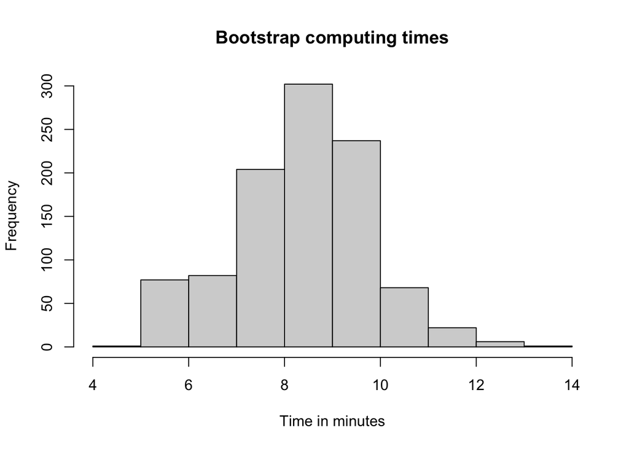

```r
numextract <- function(string){
  as.numeric(str_extract(string, "\\-*\\d+"))
}

files <- files[order(numextract(files))]

sr <- plyr::llply(paste0("intermediates/", files), function(x){
  load(x)
  return(list=(r=boot))}, .progress = "none")

names(sr) <- paste0("boot", numextract(files))

# Rearrange hierarchy of results to method > iteration > scenario > measures
sr <- do.call(function(...) Map(list, ...), sr)

# time elapsed per bootstrap run (not used in the manscript)
hist(unlist(sr$time.elapsed.sec)/ 60,
     xlab="Time in minutes",
     main="Bootstrap computing times")
```

```r
nmethods <- 12
index <- c(1:5,7:12) # all 12 but CoxTVridge, which did not converge in the full sample
```

### 2.4.1 Table 1

```r
# out-of-bag time averaged Ctd
coob <- sapply(1:nboot, function(x){
  sapply(sr$cstats.oob[[x]][index], function(xx) xx$Ctd)})
col1 <- round(apply(coob, 1, mean), 3)
col2 <- round(apply(coob, 1, sd), 3)

# out-of-bag Ctd for t=60 days
cfoob <- lapply(1:nboot, function(x){
  array(as.numeric(sapply(sr$cstats.fixed.oob[[x]][index], function(xx) xx["Ctd",])), dim=c(5,11))})
cfoob <- array(unlist(cfoob), dim=c(5, 11, nboot))
col3 <- round(apply(cfoob, c(1,2), mean), 3)[1, ]
col4 <- round(apply(cfoob, c(1,2), sd), 3)[1, ]

table1 <- data.frame("method" = c("RegHazTV", "RegCumHazTV", "CoxPH", "CoxTV", "CoxPHridge",
             "RPrcsPH", "RPrcsTV", "RPssPH", "RPssTV", "RegHazPH", "RegCumHazPH"),
             "Ctd.est" = col1, "Ctd.se"=col2, "Ctd.t60"=col3, "Ctd.t60.se"=col4)
table1
```

```
#>         method Ctd.est Ctd.se Ctd.t60 Ctd.t60.se
#> 1     RegHazTV   0.698  0.044   0.742      0.043
#> 2  RegCumHazTV   0.694  0.047   0.741      0.043
#> 3        CoxPH   0.705  0.035   0.740      0.044
#> 4        CoxTV   0.683  0.057   0.736      0.045
#> 5   CoxPHridge   0.709  0.034   0.744      0.043
#> 6      RPrcsPH   0.706  0.035   0.740      0.044
#> 7      RPrcsTV   0.693  0.043   0.736      0.046
#> 8       RPssPH   0.705  0.035   0.739      0.045
#> 9       RPssTV   0.677  0.060   0.732      0.046
#> 10    RegHazPH   0.713  0.035   0.752      0.042
#> 11 RegCumHazPH   0.713  0.035   0.751      0.042
```

### 2.4.2 Calibration figures

```r
methods.ae <- c("RegHazTV", "RegCumHazTV", "CoxPH", "CoxTV", "CoxPHridge",  "CoxTVridge",
             "RPrcsPH", "RPrcsTV", "RPssPH", "RPssTV", "RegHazPH", "RegCumHazPH")

dir <- "figures/"
predict.grid <- 1-predict.grid
m=t=1
for(t in 1:length(fixed.times)){
  if(fixed.times[t] %in% c(60, 120, 180)){
    setEPS()
    postscript(file=paste0(dir, "cal_ae", "_t",fixed.times[t], ".eps"),
               width = 8, height = 7)
    par(mfrow=c(3,4))
    par(font.main = 1)
    for(m in index){

      cal <- 1-sapply(sr$cal.oob, function(x) x[[m]][[t]]$hare.cal.obs)
      calmean <- apply(cal, 1, function(x) mean(x, na.rm=TRUE))
      cal10 <- apply(cal, 1, function(x) quantile(x, probs=0.1, na.rm=TRUE))
      cal90 <- apply(cal, 1, function(x) quantile(x, probs=0.9, na.rm=TRUE))

      plot(calmean ~ predict.grid[,t], type="l", xlim=c(0,1), ylim=c(0,1), lwd=2,
           main=paste0(methods.ae[m],", t=",fixed.times[t]),
           ylab="Observed", xlab="Predicted")
      lines(cal10 ~ predict.grid[,t], lty=3, lwd=2)
      lines(cal90 ~ predict.grid[,t], lty=3, lwd=2)
      abline(0,1,lty=1,col="red")
    }
  dev.off()
  }
}
```

Done.